# More NP-Hard Problems

April 23, 2021

# Assignment Comments

## Explain your reasoning

- Just giving an answer without any explanation whatsoever is not doing the *exercise*.
- “Explain your reasoning” has been and continues to be an implicit instruction for all exercises.
- You learn by trying to explain.

## How many 3CNF formulas?

How many different formulas in 3-conjunctive normal form can be made using $n$ variables $x_1, x_2, \ldots, x_n$?

- Clauses: $C(2n,3) \in \Theta(n^3)$
- Formulas: Power set of clauses: $O(2^{n^3})$.

Find an upper bound on the *length* of a formula (counting literals, connectives, and parentheses).

- Everything is a constant multiple of the number of clauses, so length is $O(n^3)$.

**Note:** Length is polynomial (3SAT is in NP), but the number of instances of 3SAT is superpolynomial.

## DNF-SAT

Polynomial time solver (so DNF-SAT is in P)

```
for each clause
  if the clause does not contain a literal and its negation
    return true
return false
```

Argument is bogus because repeatedly distributing is going to be superpolynomial time.

# Polynomial-time reductions

## How to show a problem is NP-hard

> **To prove that problem $A$ is NP-hard, reduce a known NP-hard problem to $A$.**
- In other words, show that, if you had a polynomial-time solver for $A$, you could build a polynomial-time solver for some known NP-hard problem.
- To show a problem is NP-complete, show that it is NP-hard, and also check that it is in NP.

## Examples So Far

- SAT is NP-hard (and NP-complete).
  - First example; proof “from scratch” (CS-135)
- 3SAT is NP-hard (and NP-complete).
  - If I could solve 3SAT in polynomial time, I’d be able to solve SAT in polynomial time. But then I could solve any problem in NP in polynomial time.
- MaxIndSet is NP-hard.
  - If I had a polynomial time solver for MaxIndSet, I could use it to solve 3SAT in polynomial time.
    - Given an instance of 3SAT (i.e., a 3CNF formula), convert in to a graph using clever gadgets.
    - Use your MaxIndSet solver on this graph.
    - If the size of the independent set equals the number of clauses in your formula, the formula is satisfiable.

# Other NP-Hard Graph Problems

## MinVertexCover (from MaxIndSet)

- **MinVertexCover:** Given a graph $G$, what is size of the smallest subset of vertices you can select so that every edge is touched?
  - Suppose you had a polynomial-time solver for MinVertexCover.
  - Given an instance of MaxIndSet (a graph $G$), use your MinVertexCover solver to find a minimum vertex cover $C$.
  - Now let $S = V \setminus C$ (the vertices not in $C$).
    - No two vertices of $S$ are joined by an edge, because you took away all the vertices in a vertex cover.
    - So $S$ is an independent set.
      - And $S$ is maximal, because $C$ was minimal.
    - So you just solved MaxIndSet!
    - Forming the complement takes linear time, so this is a polynomial-time reduction. Therefore MinVertexCover is NP-hard.

## MaxClique (from MaxIndSet)

- **MaxClique:** What is the size of the largest *complete* subgraph of a given graph?
  - Suppose you had a polynomial-time solver for MaxClique.
  - Someone asks you to solve an instance of MaxIndSet, i.e., given a graph $G$, can you find a maximum independent set?
    - Form the *edge complement* $\overline{G}$ of $G$. ($\overline{G}$ has edges exactly where $G$ doesn’t.)
      - This takes $O(V^2)$ time (using adjacency matrices).
    - Use your MaxClique solver on $\overline{G}$.
    - You have found the largest set of vertices that are mutually connected in $\overline{G}$. So none of these vertices are connected in $G$.
    - So you just solved MaxIndSet in polynomial time!
    - Therefore, MaxClique is NP-hard.

# Graph Coloring

## 3Color

**3Color:** Given a graph $G$, is there a coloring of $G$ that uses only 3 colors?

- 3Color is in NP, because it is easy to check whether a proposed 3-coloring is legal in $O(V^2)$ time.

## Coloring Gadgets

See the Jamboard.

1. Suppose a 3-coloring (using red, green, blue) of the first gadget makes $u$ and $v$ both green. What color(s) could $z$ be?
2. Suppose a 3-coloring (using red, green, blue) of the first gadget makes $u$ green and $v$ blue. What color(s) could $z$ be?
3. Suppose a 3-coloring (using red, green, blue) of the second gadget makes $w$, $x$, and $y$ all green. What color(s) could $z$ be?

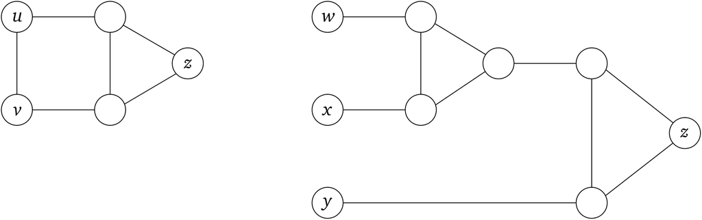

## 3Color (from 3SAT)

- Suppose you have a polynomial-time solver for 3Color.
- Someone asks to to solve an instance of 3SAT (i.e., you are given a 3CNF formula: is it satisfiable?)
  - Convert the formula into a graph using gadgets.
    - Do it in polynomial time. (See Jamboard.)
  - Use your 3Color solver. (WLOG T=green, F=red)
    - Graph is 3-colorable $\Leftrightarrow$ formula is satisfiable. (The greens are true.)
  - You just solved 3SAT in polynomial time!
  - Therefore 3Color is NP-hard (and NP-complete).